# RED WINE DATA by Paula Hwang

This report explores a dataset containing quality and attributes for approximately 1600 wines.

# Loading the csv file

```
## [1] "C:/Users/Alexander Smith/Desktop/wine-data"
```

Our dataset consists of 13 variables, with almost 1599 observations.

#### Display variables and observations

```
## [1] 1599   13
```

#### Display the summary of the data

```
## 'data.frame':    1599 obs. of  13 variables:
##  $ X                   : int  1 2 3 4 5 6 7 8 9 10 ...
##  $ fixed.acidity       : num  7.4 7.8 7.8 11.2 7.4 7.4 7.9 7.3 7.8 7.5 ...
##  $ volatile.acidity    : num  0.7 0.88 0.76 0.28 0.7 0.66 0.6 0.65 0.58 0.5 ...
##  $ citric.acid         : num  0 0 0.04 0.56 0 0 0.06 0 0.02 0.36 ...
##  $ residual.sugar      : num  1.9 2.6 2.3 1.9 1.9 1.8 1.6 1.2 2 6.1 ...
##  $ chlorides           : num  0.076 0.098 0.092 0.075 0.076 0.075 0.069 0.065 0.073 0.071 ...
##  $ free.sulfur.dioxide : num  11 25 15 17 11 13 15 15 9 17 ...
##  $ total.sulfur.dioxide: num  34 67 54 60 34 40 59 21 18 102 ...
##  $ density             : num  0.998 0.997 0.997 0.998 0.998 ...
##  $ pH                  : num  3.51 3.2 3.26 3.16 3.51 3.51 3.3 3.39 3.36 3.35 ...
##  $ sulphates           : num  0.56 0.68 0.65 0.58 0.56 0.56 0.46 0.47 0.57 0.8 ...
##  $ alcohol             : num  9.4 9.8 9.8 9.8 9.4 9.4 9.4 10 9.5 10.5 ...
##  $ quality             : int  5 5 5 6 5 5 5 7 7 5 ...
```

#### Display a summary another way

```
##        X          fixed.acidity   volatile.acidity  citric.acid
##  Min.   :   1.0   Min.   : 4.60   Min.   :0.1200   Min.   :0.000
##  1st Qu.: 400.5   1st Qu.: 7.10   1st Qu.:0.3900   1st Qu.:0.090
##  Median : 800.0   Median : 7.90   Median :0.5200   Median :0.260
##  Mean   : 800.0   Mean   : 8.32   Mean   :0.5278   Mean   :0.271
##  3rd Qu.:1199.5   3rd Qu.: 9.20   3rd Qu.:0.6400   3rd Qu.:0.420
##  Max.   :1599.0   Max.   :15.90   Max.   :1.5800   Max.   :1.000
##  residual.sugar     chlorides       free.sulfur.dioxide
##  Min.   : 0.900   Min.   :0.01200   Min.   : 1.00
##  1st Qu.: 1.900   1st Qu.:0.07000   1st Qu.: 7.00
##  Median : 2.200   Median :0.07900   Median :14.00
##  Mean   : 2.539   Mean   :0.08747   Mean   :15.87
##  3rd Qu.: 2.600   3rd Qu.:0.09000   3rd Qu.:21.00
##  Max.   :15.500   Max.   :0.61100   Max.   :72.00
##  total.sulfur.dioxide    density             pH          sulphates
##  Min.   :  6.00       Min.   :0.9901   Min.   :2.740   Min.   :0.3300
##  1st Qu.: 22.00       1st Qu.:0.9956   1st Qu.:3.210   1st Qu.:0.5500
##  Median : 38.00       Median :0.9968   Median :3.310   Median :0.6200
##  Mean   : 46.47       Mean   :0.9967   Mean   :3.311   Mean   :0.6581
##  3rd Qu.: 62.00       3rd Qu.:0.9978   3rd Qu.:3.400   3rd Qu.:0.7300
##  Max.   :289.00       Max.   :1.0037   Max.   :4.010   Max.   :2.0000
##     alcohol         quality
##  Min.   : 8.40   Min.   :3.000
##  1st Qu.: 9.50   1st Qu.:5.000
##  Median :10.20   Median :6.000
##  Mean   :10.42   Mean   :5.636
##  3rd Qu.:11.10   3rd Qu.:6.000
##  Max.   :14.90   Max.   :8.000
```

# Univariate Plots Section

# Univariate Analysis

***A** First, I made a plot to find out what it looks like as a plot. I decided to pick quality for the univariate Analysis.

source: https://stackoverflow.com/questions/38788357/change-bar-plot-colour-in-geom-bar-with-ggplot2-in-r

#### Plot a histogram

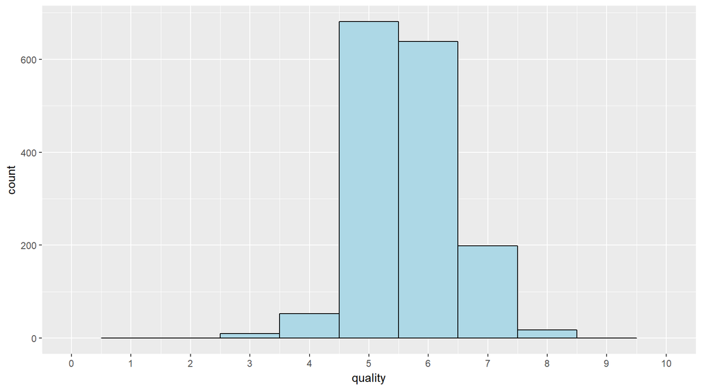

Because my plot looks slightly skewed, I plan to transform it into a normal distribution. I have two options: sqrt or log.

*source: https://stats.stackexchange.com/questions/74537/log-or-square-root-transformation-for-arima

***B)** This is my attempt of using sqrt to transform into a normal distribution. It looks slightly normal.

#### Plot the histogram by adding scale_y_sqrt()

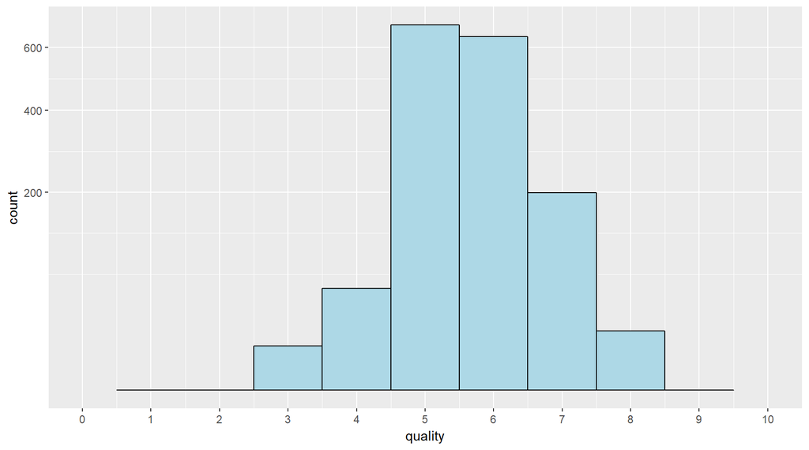

#### Plot a histogram with log10

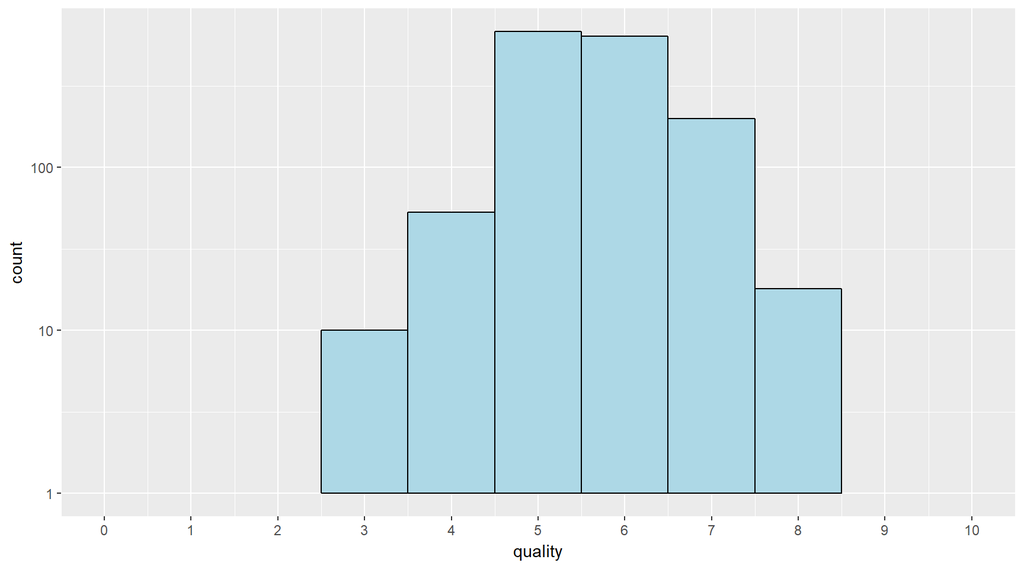

### What is the structure of your dataset?

- Our dataset consists of 13 variables, with almost 1599 observations.

For more information, read [Cortez et al., 2009].

Input variables (based on physicochemical tests): 1 - fixed acidity (tartaric acid - g / dm^3) 2 - volatile acidity (acetic acid - g / dm^3) 3 - citric acid (g / dm^3) 4 - residual sugar (g / dm^3) 5 - chlorides (sodium chloride - g / dm^3 6 - free sulfur dioxide (mg / dm^3) 7 - total sulfur dioxide (mg / dm^3) 8 - density (g / cm^3) 9 - pH 10 - sulphates (potassium sulphate - g / dm3) 11 - alcohol (% by volume) Output variable (based on sensory data): 12 - quality (score between 0 and 10)

#### Display the dimmensions of an Object like in the begining

```
## [1] 1599   13
```

### What is/are the main feature(s) of interest in your dataset?

- My main feature of interest is the quality of the wine.

### What other features in the dataset do you think will help support your investigation into your feature(s) of interest?

- I believe that that I am interesting in all the variables such as volatile.acidity, residual.sugar, free.sulfur.dioxide, density, sulphates, fixed acidity, citric-acid, chlorides, pH, and alcohol. ###Plotting each variable in histogram in univariate experimentation way

```
## <ScaleContinuousPosition>
##  Range:
##  Limits:    0 --    1
```

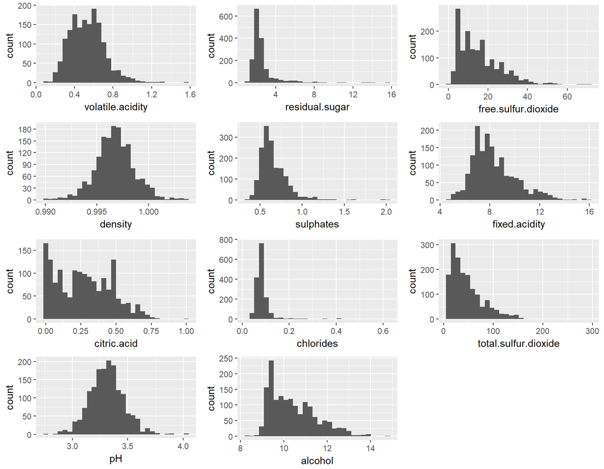

### Did you create any new variables from existing variables in the dataset?

Yes, I did create new variables to assembled all the plots in one box to faciliate my observations.

### Of the features you investigated, were there any unusual distributions? ###Did you perform any operations on the data to tidy, adjust, or change the form ###of the data? If so, why did you do this?

I used the log10 or squrt by transforming my plots into a normal distribution. I am going to quote from r-statistics.com to explain why I made them normal. “The need for data transformation can depend on the modeling method that you plan to use. For linear and logistic regression, for example, you ideally want to make sure that the relationship between input variables and output variables is approximately linear, that the input variables are approximately normal in distribution, and that the output variable is constant variance (that is, the variance of the output variable is independent of the input variables). You may need to transform some of your input variables to better meet these assumptions.”

source: https://www.r-statistics.com/2013/05/log-transformations-for-skewed-and-wide-distributions-from-practical-data-science-with-r/

# Bivariate Plots Section

I am going to use scatterplots to check the relationship between two variables.

# loading the libraries

GGpairs can be useful for exploring the relationships between several columns of data in a data frame

source: https://stackoverflow.com/questions/45044157/how-do-you-add-jitter-to-a-scatterplot-matrix-in-ggpairs

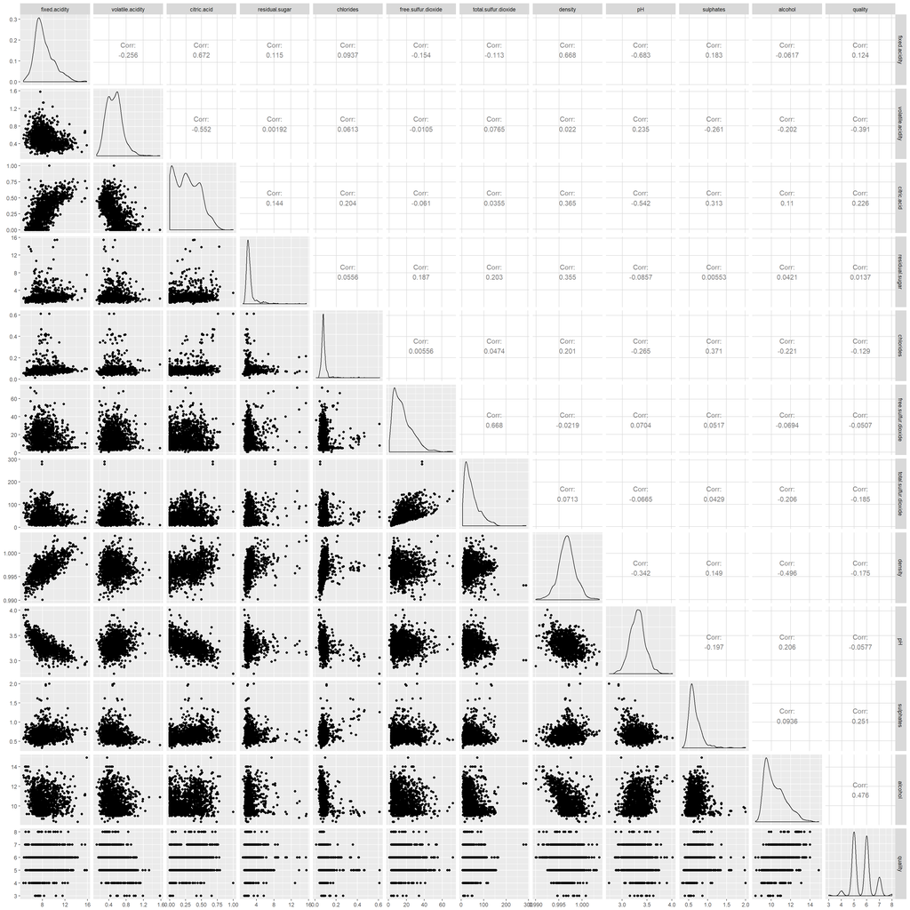

-Also, the citric acid do have connection to pH and density.

-The ones that are little bit closer to citric acid are volatile acidity and fixed acidity. –Meaning, they are probably in relationship.

First, I need to double check by adding red line or linear regression to see the connection connection between two supportive variables.

#### I am comparing pH and density.

Density goes down while ph goes up… I am surprized that they are look very different to each other. I expected them to have a positive correlation because they have normal plots. This plot goes to an opposite dirrection.

# Create a scatterplors to check two variables: ph and density

[figure not shown]

Comparing ph and citric acid, it goes down.

# Create a scatterplots between citric acid and pH

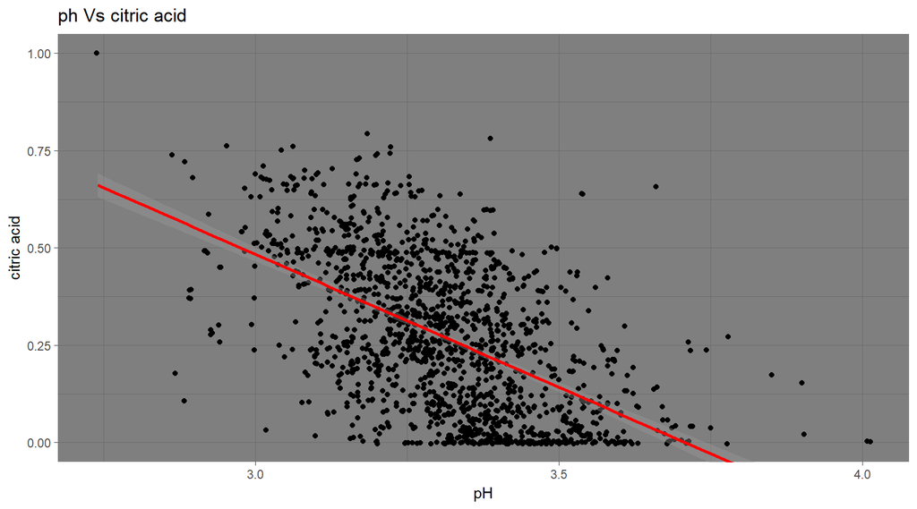

Despite that density and Ph are both normal…; it looks different to citric acid —comparing to pH and citric acid (check my previous plot).

# Create a scatterplots between citric acid and density

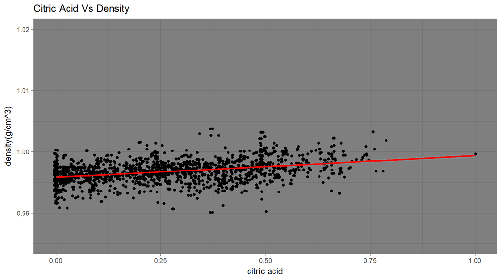

Here is the relationship between fixed acidity and ph. It is falling down slightly.

# Create a scatterplots between ph and fixed acidity

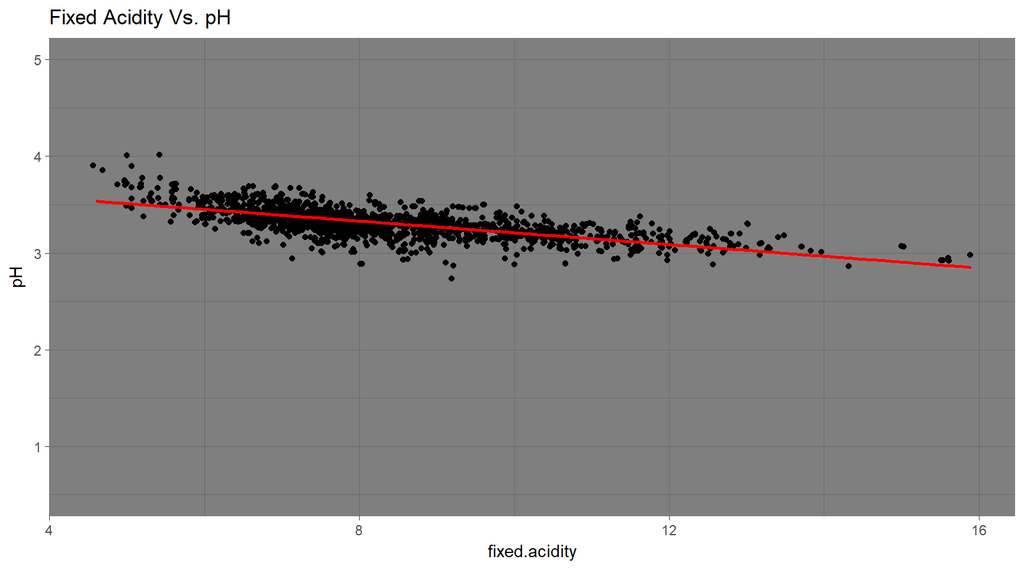

Alright, I am going to compare fixed acidity and citric.acid. They are SO connected to each other. Definately a positive one.

# Create a scatterplots between citric acid and fixed acidity

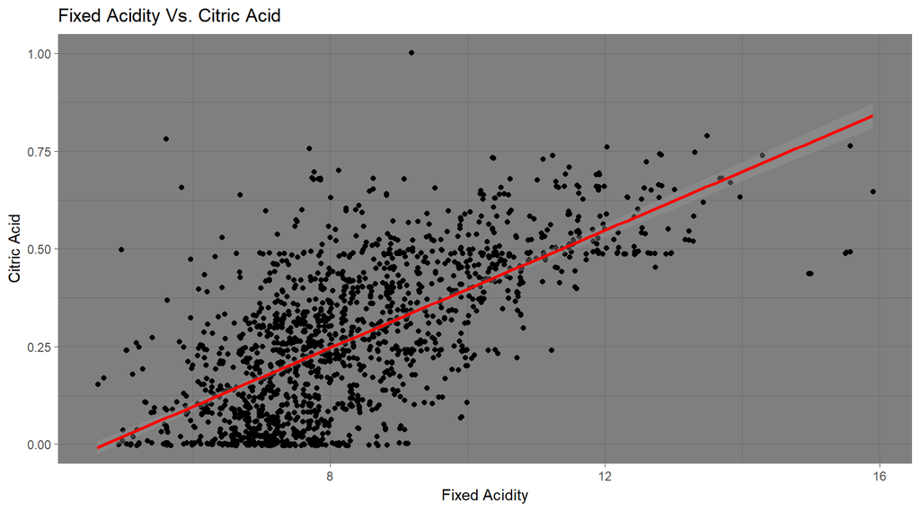

Next, I am going to plot volatile.acid and fixed.acidity. It definately feels like it is going down.

# Create a scatterplots between fixed acidity and volatile acidity

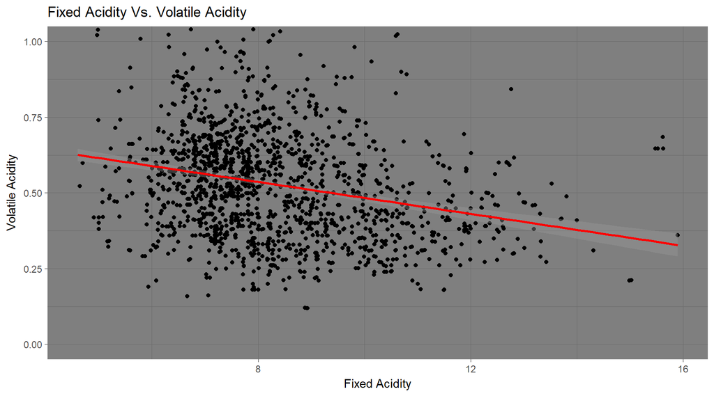

Let’s see how it looks like with pH and volatile.acidity. It definiately looks positive because it is escalating.

# Create a scatterplots between ph and volatile acidity

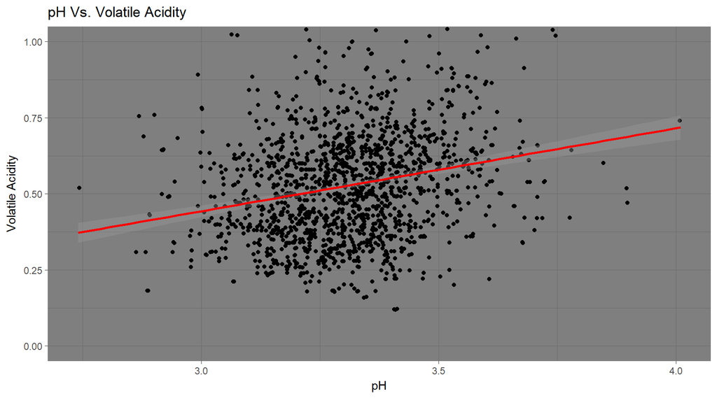

Next, I am going to compare volatile.acidity and density…It looks like to me there is slightly increase from this plot.

# #Create a scatterplots between density and volatile acidity

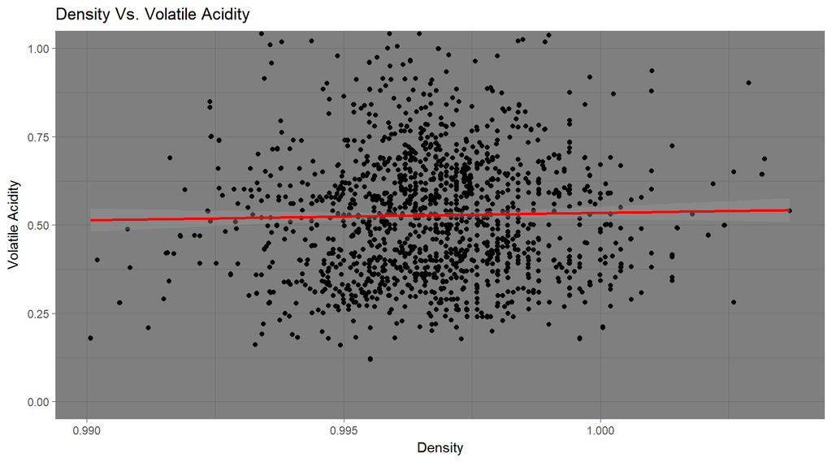

This is how I categorized visually based on my previous plots.

density & citric. acidity, citric & fixed acidity, volatile. acidity & pH, density & volatile acidity.

##### Negative correlation: (4 neg)

pH & density, pH & citric acidity, pH & fixed acidity, volatile.acidity & fixed acidity.

Another way to verify if they are negative or positive correlation. I am using a cor.test in programming.

# Check the correlation between two varriables and categorize them between negative and postive

```
##
##  Pearson's product-moment correlation
##
## data:  df$pH and df$density
## t = -14.53, df = 1597, p-value < 2.2e-16
## alternative hypothesis: true correlation is not equal to 0
## 95 percent confidence interval:
##  -0.3842835 -0.2976642
## sample estimates:
##        cor
## -0.3416993
```

```
##
##  Pearson's product-moment correlation
##
## data:  df$pH and df$citric.acid
## t = -25.767, df = 1597, p-value < 2.2e-16
## alternative hypothesis: true correlation is not equal to 0
## 95 percent confidence interval:
##  -0.5756337 -0.5063336
## sample estimates:
##        cor
## -0.5419041
```

```
##
##  Pearson's product-moment correlation
##
## data:  df$pH and df$fixed.acidity
## t = -37.366, df = 1597, p-value < 2.2e-16
## alternative hypothesis: true correlation is not equal to 0
## 95 percent confidence interval:
##  -0.7082857 -0.6559174
## sample estimates:
##        cor
## -0.6829782
```

```
##
##  Pearson's product-moment correlation
##
## data:  df$fixed.acidity and df$volatile.acidity
## t = -10.589, df = 1597, p-value < 2.2e-16
## alternative hypothesis: true correlation is not equal to 0
## 95 percent confidence interval:
##  -0.3013681 -0.2097433
## sample estimates:
##        cor
## -0.2561309
```

```
##
##  Pearson's product-moment correlation
##
## data:  df$pH and df$volatile.acidity
## t = 9.659, df = 1597, p-value < 2.2e-16
## alternative hypothesis: true correlation is not equal to 0
## 95 percent confidence interval:
##  0.1880823 0.2807254
## sample estimates:
##       cor
## 0.2349373
```

```
##
##  Pearson's product-moment correlation
##
## data:  df$density and df$citric.acid
## t = 15.665, df = 1597, p-value < 2.2e-16
## alternative hypothesis: true correlation is not equal to 0
## 95 percent confidence interval:
##  0.3216809 0.4066925
## sample estimates:
##       cor
## 0.3649472
```

[output not shown]

Again the negative correlarion by using Pearson method in programming are: - ph & density - ph & citrict acid - ph & fixed acidity - fixed acidity & volatile-acidity

-I am going to use ggcorr as an another method to check the relationshipness between two variables.

#create another correlation table to check the relationship between two variables

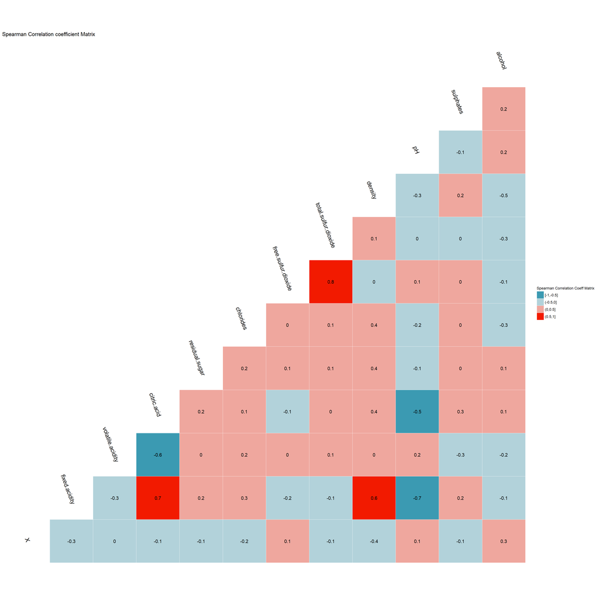

I guess this method is easier because you can see that the bright red color is indicating the strongest relationship between two variables.These indicate the list of strongest relationship.

1. Free sulfur dioxide & total sulfur dioxide

2. Fixed acidity & Citric Adid

3. density & fixed acidity

I always thought that ph and density would be in the list. Turns out that their relationship is not the strongest. I need to keep my eyes on the fixed acidity,

##### Checking out the boxplots

–> Quality of Wine and other variables in boxplots

This time I am going to explore the data by displaying the scatterplots. My main variable of my interest would be the quality of the wine. I am going to observe the quality of the wine along with all other variables. The question is what makes a red wine a good quality? or what define a good quality of the red wine?

#Now create the boxplots for each variables + quality

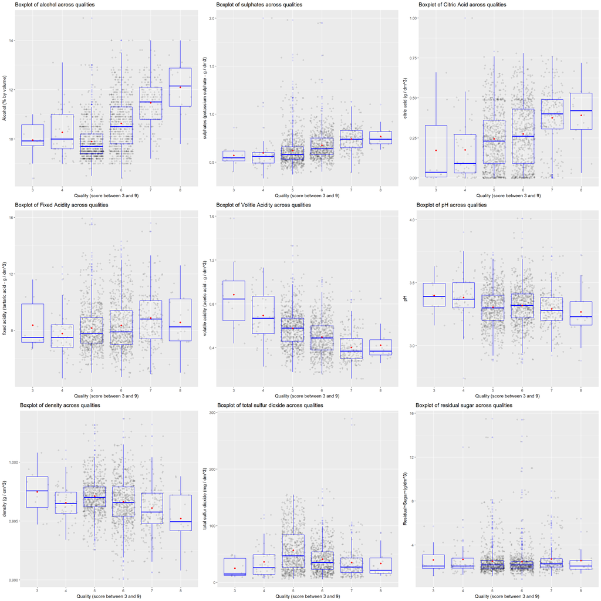

I am going to classify based on the previous observations.All these tiny dots will represent the quality of the wine and remain the same.

1. The quality of the wine gets better if we add more alcohol.

2. I am suprized that we need to add more sulphates to improve the quality of the wine.

3. The more I add Citric acid, the better quality the wine will be.[This is the one that I need to keep my eyes on this variable.]

4. The wine gets better with slight increase of the fixed acidity.

5. The quality is falling down when the volatile acidity is increased.

7. The quality of the wine degrades when density goes up.

9.Residual sugar does not change the quality of the wine –no matter how much ammount you add sugar.

# Bivariate Analysis

### Talk about some of the relationships you observed in this part of the  
##investigation. How did the feature(s) of interest vary with other features in  
##the dataset?

source: https://www.emathzone.com/tutorials/basic-statistics/positive-and-negative-correlation.html#ixzz5OmFgYWlq

After observing the table, I see two similarity between density & citric acid and pH & citrict acid. They both have normal looking (symmetrical) plot. I have expected that these variables may have the strongest relationship.

After testing each different methods by plotting the variables with red line, in Pearson method of finding correlation, and in spearman correlation method –it turns out that

-the fixed acidity & density, -Free sulfur dioxide & total sulfur dioxide, -and fixed acidity & citric acid

have the strongest relationship.

Therefore, my expectation is wrong.

### Did you observe any interesting relationships between the other features  
###(not the main feature(s) of interest)?

I have compared the ph, density, citric.accidity, and others variables that might seem to be correlated to each other.

### What was the strongest relationship you found?

The List of the strongest relationship:

1. Free sulfur dioxide & total sulfur dioxide

2. Fixed acidity & Citric Adid

3. density & fixed acidity

# Multivariate Plots Section

# Multivariate Analysis

### Talk about some of the relationships you observed in this part of the ###investigation. Were there features that strengthened each other in terms of ###looking at your feature(s) of interest?

During my investigation, the variables that i have been observing would be density, alcohol, sulphates and quality of the wine.

According to my previous investigation, I am already aware that adding more alcohol would improve the quality of the wine. I am going to attempt to correlate with density (–a slight increase of the density would makes the quality of the wine worse). Because I am curious. I want to check the relationship between the density, alcohol, and quality.

We could conclude that adding less density, more alcohol could improve the overall the quality of the wine. There is no contradiction from the Bivariate examination.

# Create scatterplots with colored variable

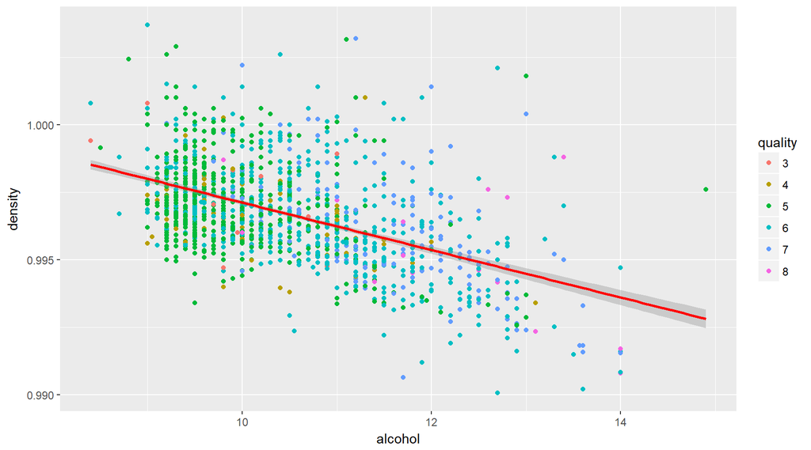

Next one looks like a positive correlation…It means that the slight of the increase of the sulphites and alcohol could make better quality. THerefore, there is no contradiction.

# Create scatterplots with colored variable

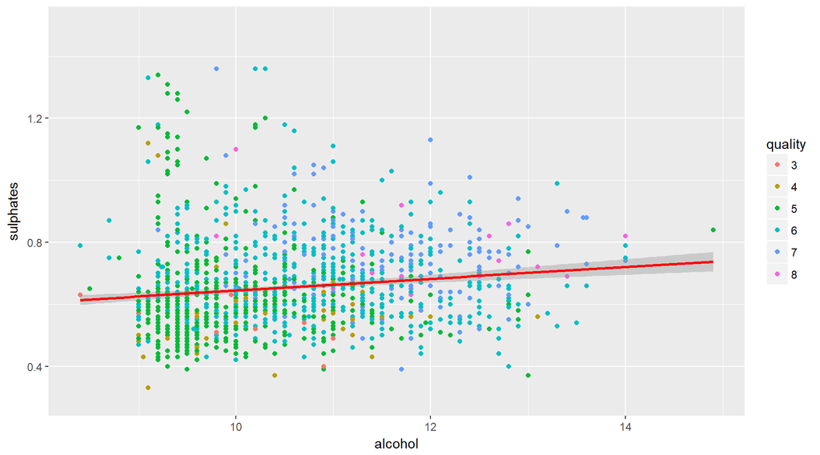

I am going to use another method and perform logistic method to check the numbers. This time, I decided to seperate the quality by using facet_wrap because …I am curious how it looks when the quality are seperated.

Previously at the bivariate experimentation, the relationship between the sulphates and quality are considered positive. However, adding alcohol as a third variable change everythhing. Turns out that the relationship between three variables like sulphates, alcohol, and quality are tiny bit negative. Actually, that does not convince me that the sulphates is making worse. I move on.

# Create scatterplots and separate each qualities with facet_wrap

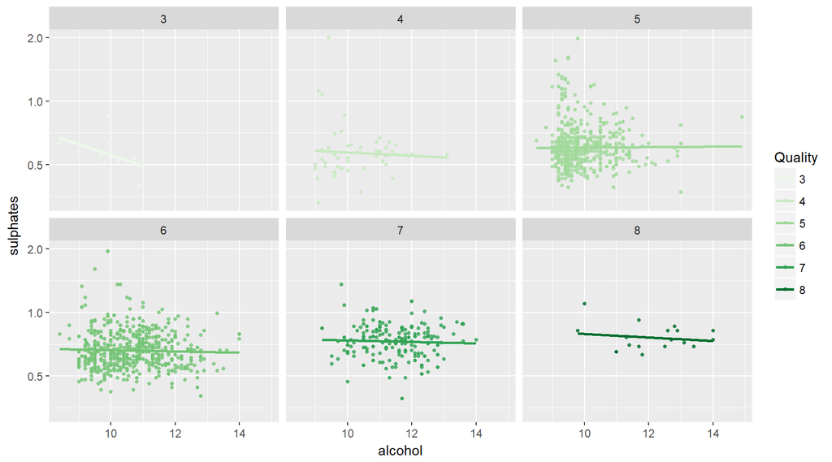

# Create scatterplots and separate each qualities with facet_wrap

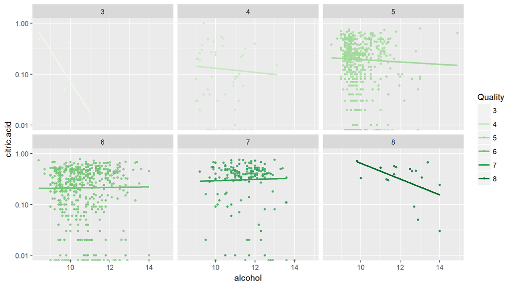

I have picked the variables the ones that had strong relationship from the bivariate experimentation. I choose fixed acidity, citric acid, and quality. These plots definately show a correlation.

# Create scatterplots and separate each qualities with facet_wrap

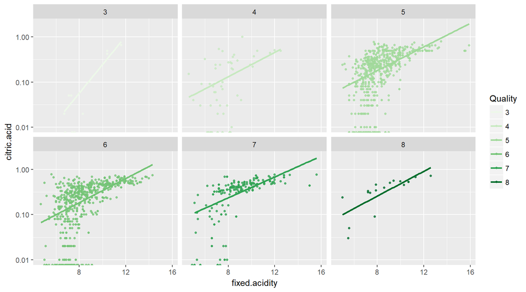

I am going to attempt to check the linear models to make some prediction.

source: https://stat.ethz.ch/R-manual/R-patched/library/base/html/numeric.html

```
##
## Calls:
## m1: lm(formula = as.numeric(quality) ~ alcohol, data = df)
## m2: lm(formula = as.numeric(quality) ~ alcohol + pH, data = df)
## m3: lm(formula = as.numeric(quality) ~ alcohol + pH + citric.acid,
##     data = df)
## m4: lm(formula = as.numeric(quality) ~ alcohol + pH + citric.acid +
##     volatile.acidity, data = df)
## m5: lm(formula = as.numeric(quality) ~ alcohol + pH + citric.acid +
##     volatile.acidity + fixed.acidity, data = df)
##
## ==========================================================================================
##                          m1            m2            m3            m4            m5
## ------------------------------------------------------------------------------------------
##   (Intercept)          -0.125         2.426***      1.232**       2.672***      1.751**
##                        (0.175)       (0.387)       (0.460)       (0.457)       (0.574)
##   alcohol               0.361***      0.386***      0.364***      0.334***      0.334***
##                        (0.017)       (0.017)       (0.017)       (0.017)       (0.017)
##   pH                                 -0.850***     -0.463**      -0.529***     -0.329*
##                                      (0.116)       (0.141)       (0.135)       (0.155)
##   citric.acid                                       0.521***     -0.180        -0.361**
##                                                    (0.110)       (0.121)       (0.138)
##   volatile.acidity                                               -1.361***     -1.409***
##                                                                  (0.113)       (0.114)
##   fixed.acidity                                                                 0.040**
##                                                                                (0.015)
## ------------------------------------------------------------------------------------------
##   R-squared             0.227         0.252         0.262         0.324         0.327
##   adj. R-squared        0.226         0.251         0.261         0.322         0.325
##   sigma                 0.710         0.699         0.694         0.665         0.664
##   F                   468.267       268.888       189.108       190.704       154.539
##   p                     0.000         0.000         0.000         0.000         0.000
##   Log-likelihood    -1721.057     -1694.466     -1683.339     -1613.978     -1610.469
##   Deviance            805.870       779.508       768.735       704.854       701.767
##   AIC                3448.114      3396.931      3376.678      3239.957      3234.938
##   BIC                3464.245      3418.440      3403.564      3272.220      3272.578
##   N                  1599          1599          1599          1599          1599
## ==========================================================================================
```

### Were there any interesting or surprising interactions between features?

Just like I was expected that the multivariate would have different results from univariate or bivariate examination. I am suprised that I find out something that contradicts from my bivariate investigation. Sometimes, you might remind yourself that Simpson paradox is everywhere. I learned my lesson that I need to further the experimentation to verify again the relationship in the multivariate experiment.

### OPTIONAL: Did you create any models with your dataset? Discuss the ##strengths and limitations of your model.

I made a linear models to check the result in numbers instead of the plots. The strenght is that I find it easier to read the numbers on the table than plots. We know what causes the increase and decrease of the wine quality. The limitation of my model is that is hard to predict what makes bad and good quality. Also, all my p-values are all 0… meaning it is harder to interpret the confident interval in this experimentation.(I am 0% confident…)

# Final Plots and Summary

Here are my three I like and find helpful to understand what makes a good and bad quality of the wine.

### Plot One

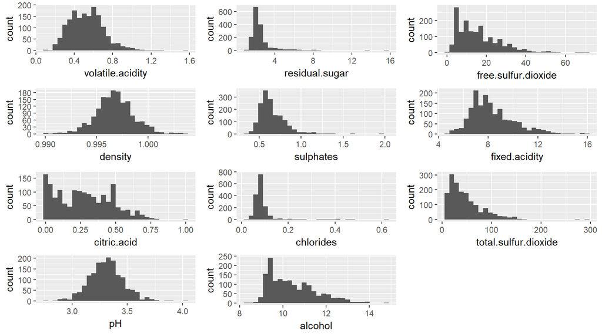

### Description One

The main reason why I pick this plot because it helps me to observe the single variable histograms very quickly. I could easily categorize which one is a normal distribution.

### Plot Two

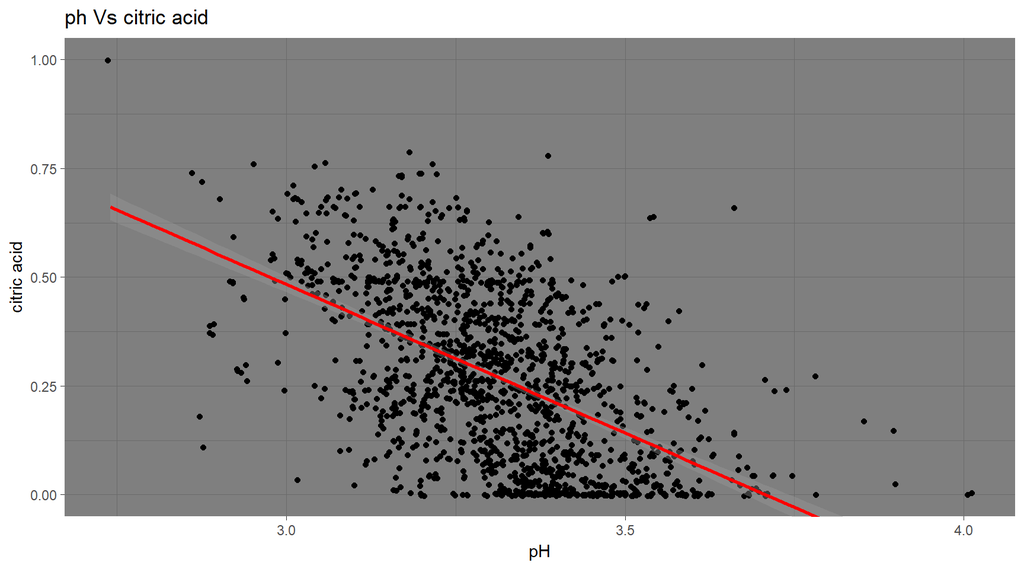

### Description Two

Let’s rexamine the citric acid and pH. We should keep eyes the relationship of citrid acid with other variable such as ph.

### Plot Three

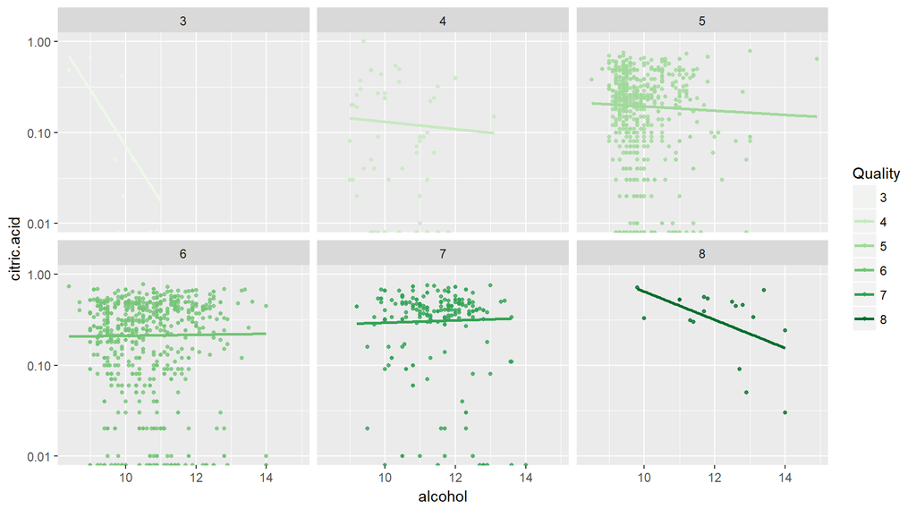

### Description Three

I choose this one because I want to point out how citric acid , alcohol, and quality are very different when we examine in multivariate experimentation. I clearly see that the quality 6 and 7 are in slightly better. Overall, that does not convince me that the citric acid is making a better quality because most of the report from quality 3,4,5, and 8 indicate that the wine got worse. # Reflection

At first, I have concluded that adding more citric acid in wine would improve the quality of the wine. I was not sure if I should conclude that citric acid is one that is decreasing of the quality because majority of the plots with citric acid skewed positively.

I have suspected since in the begining that there is some Simpson paradox moment going on during the examination. As I progress, I kept being skeptical about what I saw. I started to understand that I have to further the research from univariate, bivariate, and multivariate to examine the differences of the variables relationship. It is almost like having one child in the family can affect two parents’s life. I find it really facinating.I would suggest to re-examine again other variables beside alcohol and quality in multivariate examination.

To improve the research, I would love to interpret the confidence interval and have the numbers in the p-values. I think the research would be strong and convincinble if I include “I am 95% confident…”